# KausInf

Mattes Grundmann, Oya Bazer, Jakob Zschocke

2023-06-07

```r
library(tidyverse)
library(lmtest)
library(sandwich)
library(MatchIt)
library(twang)
library(survey)
library(nlme)
```

```r
library(ggplot2)
library(tsModel)
```

#Es wurden die benötigten Packages installiert und geladen #benötigter Datensatz wird anschließend geladen

```r
smk_data <- read_csv("https://raw.githubusercontent.com/gckc123/Causal_Analysis_Addiction_Examples/main/smoking_psyc_distress.csv")
smk_data$remoteness <- as.factor(smk_data$remoteness)
```

#Matching Funktion wird ausgeführt, um die Gruppen vergleichbar zu machen.

```r
smk_matching <- matchit(smoker ~ sex + indigeneity + high_school + partnered + remoteness + language + risky_alcohol + age, data = smk_data, method = "optimal", distance = "glm")

#Um die Daten komprimiert auszugeben wird hier die summary Funktion für den gematchten Datensatz angewendet.
summary(smk_matching)
```

```
##
## Call:
## matchit(formula = smoker ~ sex + indigeneity + high_school +
##     partnered + remoteness + language + risky_alcohol + age,
##     data = smk_data, method = "optimal", distance = "glm")
##
## Summary of Balance for All Data:
##               Means Treated Means Control Std. Mean Diff. Var. Ratio eCDF Mean
## distance             0.1852        0.1130          0.6304     2.0778    0.2033
## sex                  0.4938        0.4421          0.1035          .    0.0518
## indigeneity          0.0524        0.0175          0.1565          .    0.0349
## high_school          0.4220        0.6378         -0.4370          .    0.2158
## partnered            0.4630        0.6913         -0.4578          .    0.2283
## remoteness0          0.5852        0.6773         -0.1870          .    0.0921
## remoteness1          0.2177        0.1900          0.0670          .    0.0277
## remoteness2          0.1971        0.1327          0.1621          .    0.0645
## language             0.9579        0.9130          0.2234          .    0.0449
## risky_alcohol        0.6427        0.5411          0.2120          .    0.1016
## age                 51.6057       53.7824         -0.1676     0.8214    0.0441
##               eCDF Max
## distance        0.3185
## sex             0.0518
## indigeneity     0.0349
## high_school     0.2158
## partnered       0.2283
## remoteness0     0.0921
## remoteness1     0.0277
## remoteness2     0.0645
## language        0.0449
## risky_alcohol   0.1016
## age             0.1020
##
## Summary of Balance for Matched Data:
##               Means Treated Means Control Std. Mean Diff. Var. Ratio eCDF Mean
## distance             0.1852        0.1849          0.0025     1.0151    0.0002
## sex                  0.4938        0.5000         -0.0123          .    0.0062
## indigeneity          0.0524        0.0400          0.0553          .    0.0123
## high_school          0.4220        0.4127          0.0187          .    0.0092
## partnered            0.4630        0.4743         -0.0226          .    0.0113
## remoteness0          0.5852        0.6027         -0.0354          .    0.0175
```

[output cut: 9 more lines]

```
## high_school     0.0092          0.1725
## partnered       0.0113          0.1833
## remoteness0     0.0175          0.2772
## remoteness1     0.0041          0.2389
## remoteness2     0.0133          0.3226
## language        0.0041          0.1329
## risky_alcohol   0.0010          0.2678
## age             0.0390          0.3493
##
## Sample Sizes:
##           Control Treated
## All          7026     974
## Matched       974     974
## Unmatched    6052       0
## Discarded       0       0
```

#Anschließend werden die Daten für mehr Übersichtlichkeit geplottet, man sieht, dass die Mean Difference jetzt deutlich geringer geworden ist.

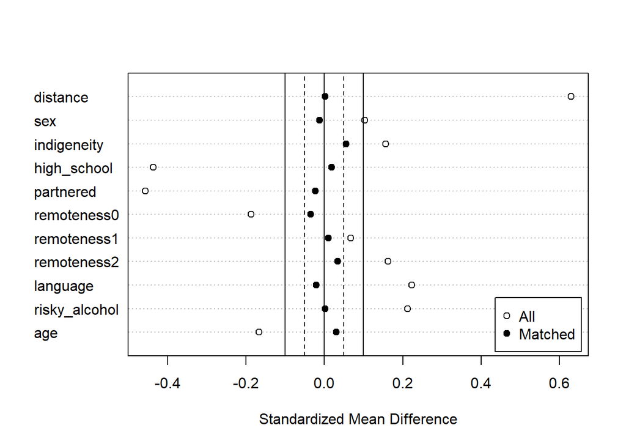

```r
plot(summary(smk_matching), abs=FALSE)
```

#Nachdem die Gruppen vergleichbar gemacht wurden, wird jetzt mittels Regression etc. der Effect von Rauchen auf Psyche gemessen.

```r
matched_data <- match.data(smk_matching)
smk_model1 <- lm(psyc_distress ~ smoker, data = matched_data, weights = weights)
summary(smk_model1)
```

```
##
## Call:
## lm(formula = psyc_distress ~ smoker, data = matched_data, weights = weights)
##
## Residuals:
##    Min     1Q Median     3Q    Max
## -7.313 -5.261 -2.261  2.700 34.739
##
## Coefficients:
##             Estimate Std. Error t value Pr(>|t|)
## (Intercept)  15.2608     0.2155  70.826  < 2e-16 ***
## smoker        2.0524     0.3047   6.735 2.15e-11 ***
## ---
## Signif. codes:  0 '***' 0.001 '**' 0.01 '*' 0.05 '.' 0.1 ' ' 1
##
## Residual standard error: 6.725 on 1946 degrees of freedom
## Multiple R-squared:  0.02278,    Adjusted R-squared:  0.02228
## F-statistic: 45.36 on 1 and 1946 DF,  p-value: 2.147e-11
```

```r
coeftest(smk_model1, vcov. = vcovCL, cluster = ~subclass)
```

```
##
## t test of coefficients:
##
##             Estimate Std. Error t value  Pr(>|t|)
## (Intercept) 15.26078    0.18357 83.1352 < 2.2e-16 ***
## smoker       2.05236    0.29287  7.0077 3.326e-12 ***
## ---
## Signif. codes:  0 '***' 0.001 '**' 0.01 '*' 0.05 '.' 0.1 ' ' 1
```

```r
coefci(smk_model1, vcov. = vcovCL, cluster = ~subclass, level = 0.95)
```

```
##                 2.5 %    97.5 %
## (Intercept) 14.900774 15.620787
## smoker       1.477986  2.626737
```

```r
smk_model2 <- lm(psyc_distress ~ smoker + sex + indigeneity + high_school + partnered + remoteness + language + risky_alcohol + age, data = matched_data, weights = weights)
summary(smk_model2)
```

```
##
## Call:
## lm(formula = psyc_distress ~ smoker + sex + indigeneity + high_school +
##     partnered + remoteness + language + risky_alcohol + age,
##     data = matched_data, weights = weights)
##
## Residuals:
##     Min      1Q  Median      3Q     Max
## -10.248  -4.406  -1.748   2.677  34.198
##
## Coefficients:
##               Estimate Std. Error t value Pr(>|t|)
## (Intercept)   20.98300    1.02957  20.380  < 2e-16 ***
## smoker         2.05594    0.29643   6.936 5.49e-12 ***
## sex           -0.84844    0.30543  -2.778  0.00553 **
## indigeneity    0.71561    0.72464   0.988  0.32350
## high_school   -0.13068    0.31555  -0.414  0.67882
## partnered     -2.27879    0.30034  -7.587 5.04e-14 ***
## remoteness1   -0.10904    0.37838  -0.288  0.77324
## remoteness2   -0.48268    0.40000  -1.207  0.22769
## language       0.31060    0.78642   0.395  0.69292
## risky_alcohol -0.04213    0.32257  -0.131  0.89609
## age           -0.08498    0.01169  -7.268 5.27e-13 ***
## ---
## Signif. codes:  0 '***' 0.001 '**' 0.01 '*' 0.05 '.' 0.1 ' ' 1
##
## Residual standard error: 6.535 on 1937 degrees of freedom
## Multiple R-squared:  0.08131,    Adjusted R-squared:  0.07657
## F-statistic: 17.14 on 10 and 1937 DF,  p-value: < 2.2e-16
```

```r
coeftest(smk_model2, vcov. = vcovCL, cluster = ~subclass)
```

```
##
## t test of coefficients:
##
##                Estimate Std. Error t value  Pr(>|t|)
## (Intercept)   20.983001   1.106654 18.9608 < 2.2e-16 ***
## smoker         2.055939   0.293548  7.0038 3.424e-12 ***
## sex           -0.848438   0.309643 -2.7400  0.006199 **
## indigeneity    0.715614   0.743268  0.9628  0.335771
## high_school   -0.130683   0.324392 -0.4029  0.687099
## partnered     -2.278793   0.301208 -7.5655 5.934e-14 ***
## remoteness1   -0.109040   0.382795 -0.2849  0.775787
## remoteness2   -0.482682   0.409110 -1.1798  0.238210
## language       0.310598   0.908526  0.3419  0.732485
## risky_alcohol -0.042134   0.327350 -0.1287  0.897599
## age           -0.084981   0.011135 -7.6317 3.611e-14 ***
## ---
## Signif. codes:  0 '***' 0.001 '**' 0.01 '*' 0.05 '.' 0.1 ' ' 1
```

```r
coefci(smk_model2, vcov. = vcovCL, cluster = ~subclass, level = 0.95)
```

```
##                    2.5 %      97.5 %
## (Intercept)   18.8126422 23.15335935
## smoker         1.4802364  2.63164188
## sex           -1.4557070 -0.24116837
## indigeneity   -0.7420744  2.17330331
## high_school   -0.7668761  0.50551060
## partnered     -2.8695187 -1.68806716
## remoteness1   -0.8597748  0.64169401
## remoteness2   -1.2850237  0.31965914
## language      -1.4711929  2.09238922
## risky_alcohol -0.6841293  0.59986187
## age           -0.1068197 -0.06314286
```

Appendix 2

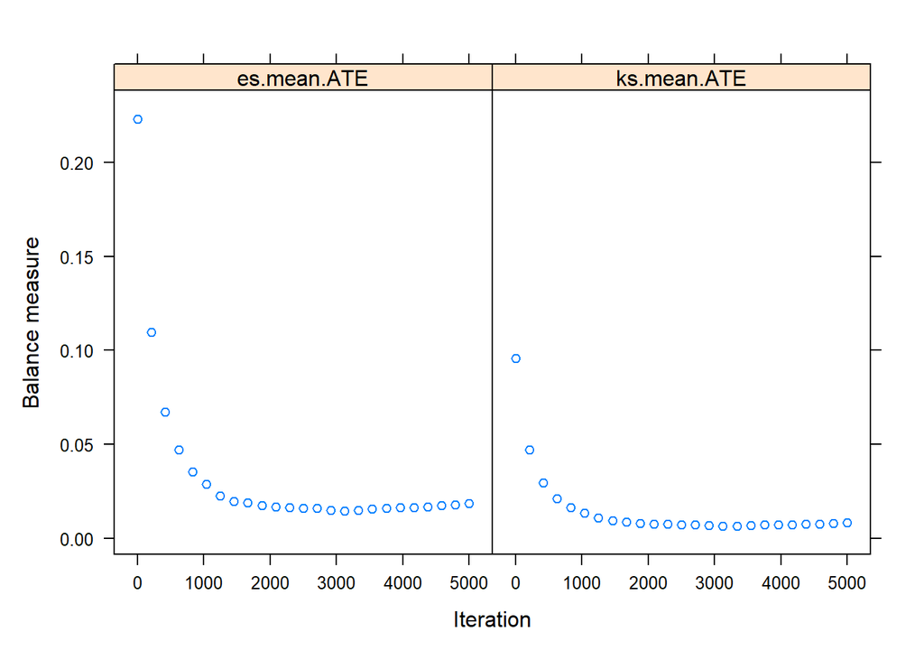

```r
#Here starts the part for IPTW method. The same data is being used, with remoteness variable recoded as factor variable.

smk_iptw <- ps(smoker ~ sex + indigeneity + high_school + partnered + remoteness + language + risky_alcohol + age, interaction.depth = 3, data = as.data.frame(smk_data), n.tree = 5000, estimand = "ATE", verbose = FALSE)

plot(smk_iptw)
```

```r
bal.table(smk_iptw)
```

```
## $unw
##                tx.mn  tx.sd  ct.mn  ct.sd std.eff.sz    stat  pval    ks
## sex            0.494  0.500  0.442  0.497      0.104   3.031 0.002 0.052
## indigeneity    0.052  0.223  0.018  0.131      0.239   4.770 0.000 0.035
## high_school    0.422  0.494  0.638  0.481     -0.443 -12.820 0.000 0.216
## partnered      0.463  0.499  0.691  0.462     -0.483 -13.504 0.000 0.228
## remoteness:0   0.585  0.493  0.677  0.467     -0.195  19.793 0.000 0.092
## remoteness:1   0.218  0.413  0.190  0.392      0.070      NA    NA 0.028
## remoteness:2   0.197  0.398  0.133  0.339      0.186      NA    NA 0.064
## language       0.958  0.201  0.913  0.282      0.164   6.180 0.000 0.045
## risky_alcohol  0.643  0.479  0.541  0.498      0.204   6.169 0.000 0.102
## age           51.606 12.990 53.782 14.333     -0.153  -4.839 0.000 0.102
##               ks.pval
## sex             0.020
## indigeneity     0.250
## high_school     0.000
## partnered       0.000
## remoteness:0    0.000
## remoteness:1       NA
## remoteness:2       NA
## language        0.064
## risky_alcohol   0.000
## age             0.000
##
## $ks.mean.ATE
##                tx.mn  tx.sd  ct.mn  ct.sd std.eff.sz   stat  pval    ks ks.pval
## sex            0.449  0.498  0.448  0.497      0.002  0.051 0.959 0.001   1.000
## indigeneity    0.019  0.138  0.021  0.144     -0.012 -0.485 0.627 0.002   1.000
## high_school    0.608  0.488  0.612  0.487     -0.009 -0.217 0.828 0.004   1.000
## partnered      0.651  0.477  0.664  0.472     -0.028 -0.734 0.463 0.013   1.000
## remoteness:0   0.668  0.471  0.667  0.471      0.003  0.003 0.997 0.001   0.997
## remoteness:1   0.193  0.395  0.193  0.395     -0.001     NA    NA 0.000      NA
## remoteness:2   0.139  0.346  0.140  0.347     -0.003     NA    NA 0.001      NA
## language       0.929  0.257  0.918  0.274      0.039  0.847 0.397 0.011   1.000
## risky_alcohol  0.572  0.495  0.554  0.497      0.037  0.862 0.389 0.018   0.992
## age           53.293 13.857 53.525 14.194     -0.016 -0.373 0.709 0.016   0.999
##
## $es.mean.ATE
##                tx.mn  tx.sd  ct.mn  ct.sd std.eff.sz   stat  pval    ks ks.pval
## sex            0.449  0.498  0.448  0.497      0.002  0.056 0.955 0.001   1.000
## indigeneity    0.020  0.138  0.021  0.144     -0.012 -0.467 0.640 0.002   1.000
## high_school    0.608  0.488  0.612  0.487     -0.008 -0.215 0.830 0.004   1.000
## partnered      0.650  0.477  0.664  0.472     -0.029 -0.757 0.449 0.014   1.000
## remoteness:0   0.667  0.471  0.667  0.471      0.002  0.003 0.997 0.001   0.997
## remoteness:1   0.193  0.395  0.193  0.395      0.000     NA    NA 0.000      NA
## remoteness:2   0.139  0.346  0.140  0.347     -0.003     NA    NA 0.001      NA
## language       0.929  0.257  0.918  0.274      0.039  0.847 0.397 0.011   1.000
## risky_alcohol  0.572  0.495  0.554  0.497      0.037  0.870 0.384 0.018   0.991
## age           53.296 13.859 53.525 14.194     -0.016 -0.368 0.713 0.016   0.999
```

```r
#extract the weights
smk_data$weight <- get.weights(smk_iptw, stop.method = "es.mean")

#Schätzung des Treatment Effekts
design_iptw <- svydesign(ids = ~1, weights = ~weight, data = smk_data)
smk_model3 <- svyglm(psyc_distress ~ smoker, design = design_iptw)
summary(smk_model3)
```

```
##
## Call:
## svyglm(formula = psyc_distress ~ smoker, design = design_iptw)
##
## Survey design:
## svydesign(ids = ~1, weights = ~weight, data = smk_data)
##
## Coefficients:
##             Estimate Std. Error t value Pr(>|t|)
## (Intercept) 14.83600    0.06618 224.168  < 2e-16 ***
## smoker       1.72865    0.25771   6.708 2.11e-11 ***
## ---
## Signif. codes:  0 '***' 0.001 '**' 0.01 '*' 0.05 '.' 0.1 ' ' 1
##
## (Dispersion parameter for gaussian family taken to be 38.62049)
##
## Number of Fisher Scoring iterations: 2
```

```r
confint(smk_model3)
```

```
##                 2.5 %    97.5 %
## (Intercept) 14.706263 14.965732
## smoker       1.223468  2.233829
```

```r
#doubly robust estimation
smk_model4 <- svyglm(psyc_distress ~ smoker + sex + indigeneity + high_school + partnered + remoteness + language + risky_alcohol + age, design = design_iptw)
summary(smk_model4)
```

```
##
## Call:
## svyglm(formula = psyc_distress ~ smoker + sex + indigeneity +
##     high_school + partnered + remoteness + language + risky_alcohol +
##     age, design = design_iptw)
##
## Survey design:
## svydesign(ids = ~1, weights = ~weight, data = smk_data)
##
## Coefficients:
##                Estimate Std. Error t value Pr(>|t|)
## (Intercept)   19.904285   0.715860  27.805  < 2e-16 ***
## smoker         1.671872   0.247822   6.746 1.62e-11 ***
## sex           -0.757545   0.241068  -3.142  0.00168 **
## indigeneity    0.841129   0.569268   1.478  0.13956
## high_school   -0.145922   0.252175  -0.579  0.56284
## partnered     -2.075947   0.250193  -8.297  < 2e-16 ***
## remoteness1    0.084483   0.334046   0.253  0.80035
## remoteness2   -0.763333   0.285282  -2.676  0.00747 **
## language       1.417293   0.467557   3.031  0.00244 **
## risky_alcohol -0.233845   0.252525  -0.926  0.35446
## age           -0.081472   0.008858  -9.197  < 2e-16 ***
## ---
## Signif. codes:  0 '***' 0.001 '**' 0.01 '*' 0.05 '.' 0.1 ' ' 1
##
## (Dispersion parameter for gaussian family taken to be 36.15502)
##
## Number of Fisher Scoring iterations: 2
```

```r
confint(smk_model4)
```

```
##                     2.5 %      97.5 %
## (Intercept)   18.50101360 21.30755703
## smoker         1.18607503  2.15766846
## sex           -1.23010174 -0.28498765
## indigeneity   -0.27478393  1.95704236
## high_school   -0.64025121  0.34840649
## partnered     -2.56639078 -1.58550318
## remoteness1   -0.57033398  0.73930040
## remoteness2   -1.32256048 -0.20410520
## language       0.50075865  2.33382761
## risky_alcohol -0.72886034  0.26117022
## age           -0.09883716 -0.06410729
```

```r
#load the data from GitHub
alc_data <- read_csv("https://raw.githubusercontent.com/gckc123/Causal_Analysis_Addiction_Examples/main/home_alc.csv")
#IPTW

alc_iptw <- iptw(list(home_alc_2 ~ home_alc_1 + alc_use1 + alc_peer1 + smk1,
                      home_alc_3 ~ alc_use2 + alc_peer2 + smk2,
                      home_alc_4 ~ alc_use3 + alc_peer3 + smk3),
                 timeInvariant ~ sex,
                 data = as.data.frame(alc_data),
                 cumulative = TRUE,
                 priorTreatment = TRUE,
                 stop.method = "es.max",
                 n.trees = 10000)
```

```
## Fitting boosted model
##
## Diagnosis of unweighted analysis
## Calculating standardized differences
## Optimizing with es.max.ATE stopping rule
##    Optimized at 1079
## Diagnosis of es.max.ATE weights
##
## Fitting boosted model
##
## Diagnosis of unweighted analysis
## Calculating standardized differences
## Optimizing with es.max.ATE stopping rule
##    Optimized at 581
## Diagnosis of es.max.ATE weights
##
## Fitting boosted model
##
## Diagnosis of unweighted analysis
## Calculating standardized differences
## Optimizing with es.max.ATE stopping rule
##    Optimized at 2483
## Diagnosis of es.max.ATE weights
```

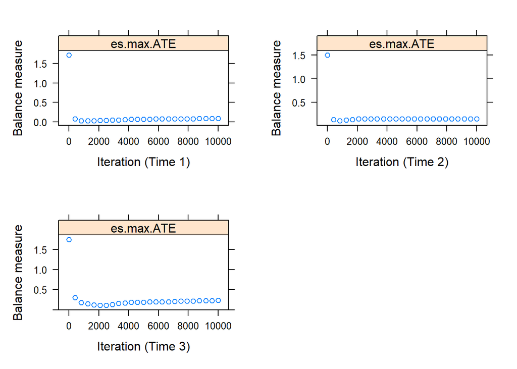

```r
plot(alc_iptw, plots = 1)
```

```r
#probably to be taken out from here (till itsa)
bal.table(alc_iptw)
```

```
## Balance at time  1 :
## $unw
##            tx.mn tx.sd ct.mn ct.sd std.eff.sz   stat     p    ks ks.pval
## home_alc_1 0.418 0.496 0.028 0.165      1.810  6.997 0.000 0.390   0.000
## alc_use1   0.253 0.438 0.094 0.291      0.527  3.221 0.001 0.160   0.044
## alc_peer1  0.456 0.501 0.278 0.448      0.393  3.102 0.002 0.178   0.018
## smk1       0.443 0.500 0.264 0.441      0.402  3.136 0.002 0.179   0.016
## sex        0.443 0.500 0.538 0.499     -0.190 -1.647 0.100 0.095   0.514
##
## $es.max.ATE
##            tx.mn tx.sd ct.mn ct.sd std.eff.sz   stat     p    ks ks.pval
## home_alc_1 0.050 0.219 0.048 0.214      0.008  0.123 0.902 0.002       1
## alc_use1   0.100 0.302 0.102 0.302     -0.004 -0.037 0.970 0.001       1
## alc_peer1  0.277 0.450 0.286 0.452     -0.021 -0.147 0.883 0.010       1
## smk1       0.265 0.444 0.273 0.446     -0.018 -0.123 0.902 0.008       1
## sex        0.521 0.503 0.533 0.499     -0.023 -0.147 0.883 0.011       1
##
##
## Balance at time  2 :
## $unw
##            tx.mn tx.sd ct.mn ct.sd std.eff.sz   stat     p    ks ks.pval
## home_alc_1 0.289 0.456 0.029 0.167      1.211  6.099 0.000 0.261   0.000
## alc_use1   0.228 0.421 0.092 0.289      0.451  3.405 0.001 0.136   0.040
## alc_peer1  0.553 0.499 0.266 0.442      0.634  5.973 0.000 0.287   0.000
## smk1       0.465 0.501 0.258 0.437      0.465  4.303 0.000 0.207   0.000
## sex        0.482 0.502 0.537 0.499     -0.109 -1.116 0.265 0.054   0.915
## alc_use2   0.298 0.460 0.119 0.324      0.528  4.097 0.000 0.179   0.002
## alc_peer2  0.649 0.479 0.377 0.485      0.555  5.836 0.000 0.272   0.000
## smk2       0.404 0.493 0.278 0.448      0.276  2.631 0.009 0.125   0.074
## home_alc_2 0.377 0.487 0.026 0.159      1.572  7.700 0.000 0.351   0.000
##
## $es.max.ATE
##            tx.mn tx.sd ct.mn ct.sd std.eff.sz   stat     p    ks ks.pval
## home_alc_1 0.052 0.222 0.046 0.209      0.028  0.410 0.682 0.006       1
## alc_use1   0.110 0.315 0.101 0.302      0.029  0.279 0.780 0.009       1
## alc_peer1  0.312 0.465 0.285 0.452      0.061  0.513 0.608 0.027       1
## smk1       0.314 0.466 0.273 0.446      0.091  0.711 0.477 0.041       1
## sex        0.493 0.502 0.533 0.499     -0.078 -0.567 0.571 0.039       1
## alc_use2   0.143 0.352 0.133 0.339      0.031  0.298 0.766 0.011       1
## alc_peer2  0.420 0.496 0.395 0.489      0.051  0.386 0.700 0.025       1
```

[output cut: 21 more lines]

```
## $es.max.ATE
##            tx.mn tx.sd ct.mn ct.sd std.eff.sz   stat     p    ks ks.pval
## home_alc_1 0.038 0.193 0.045 0.207     -0.032 -0.448 0.654 0.007       1
## alc_use1   0.087 0.283 0.100 0.300     -0.043 -0.311 0.756 0.013       1
## alc_peer1  0.313 0.467 0.284 0.451      0.064  0.280 0.780 0.029       1
## smk1       0.257 0.440 0.270 0.444     -0.031 -0.138 0.891 0.014       1
## sex        0.528 0.503 0.536 0.499     -0.017 -0.072 0.942 0.008       1
## alc_use2   0.113 0.318 0.130 0.336     -0.050 -0.369 0.713 0.017       1
## alc_peer2  0.445 0.500 0.393 0.489      0.107  0.454 0.650 0.052       1
## smk2       0.266 0.445 0.287 0.453     -0.045 -0.206 0.837 0.021       1
## home_alc_2 0.049 0.218 0.046 0.208      0.017  0.233 0.816 0.004       1
## alc_use3   0.137 0.347 0.161 0.367     -0.063 -0.429 0.668 0.023       1
## alc_peer3  0.462 0.502 0.485 0.500     -0.045 -0.193 0.847 0.022       1
## smk3       0.238 0.429 0.286 0.452     -0.107 -0.575 0.565 0.048       1
## home_alc_3 0.079 0.272 0.067 0.251      0.045  0.469 0.639 0.012       1
```

```r
#extract the unstabilised weights
alc_data$unstab_weight <- get.weights.unstab(alc_iptw, stop.method = "es.mean")[,1]

#calculate the numerators of stabilised weights
num_fm <- list(glm(home_alc_2 ~ 1, family = binomial, data = alc_data),
               glm(home_alc_3 ~ home_alc_2, family = binomial, data = alc_data),
               glm(home_alc_4 ~ home_alc_2 + home_alc_3, family = binomial, data = alc_data))

num_weights <- get.weights.num(alc_iptw, num_fm)

alc_data$stab_weight <- num_weights* alc_data$unstab_weight

#calculate the cumulative exposure
alc_data$total_home_alc = alc_data$home_alc_2 + alc_data$home_alc_3 + alc_data$home_alc_4
alc_data$total_home_alc = as.factor(alc_data$total_home_alc)

#estimate the treatment effect
design_iptw <- svydesign(ids = ~1, weights = ~stab_weight, data = alc_data)
alc_model <- svyglm(adult_alc_risky ~ total_home_alc, design = design_iptw, family = binomial)
summary(alc_model)
```

```
##
## Call:
## svyglm(formula = adult_alc_risky ~ total_home_alc, design = design_iptw,
##     family = binomial)
##
## Survey design:
## svydesign(ids = ~1, weights = ~stab_weight, data = alc_data)
##
## Coefficients:
##                 Estimate Std. Error t value Pr(>|t|)
## (Intercept)     -1.50882    0.07511 -20.088   <2e-16 ***
## total_home_alc1  0.40334    0.27554   1.464    0.143
## total_home_alc2 -0.55129    0.54824  -1.006    0.315
## total_home_alc3  1.05551    0.72068   1.465    0.143
## ---
## Signif. codes:  0 '***' 0.001 '**' 0.01 '*' 0.05 '.' 0.1 ' ' 1
##
## (Dispersion parameter for binomial family taken to be 1.000667)
##
## Number of Fisher Scoring iterations: 4
```

```r
exp(coef(alc_model))
```

```
##     (Intercept) total_home_alc1 total_home_alc2 total_home_alc3
##       0.2211703       1.4968183       0.5762044       2.8734383
```

```r
exp(confint(alc_model))
```

```
##                     2.5 %    97.5 %
## (Intercept)     0.1908713  0.256279
## total_home_alc1 0.8718510  2.569779
## total_home_alc2 0.1965796  1.688942
## total_home_alc3 0.6989714 11.812568
```

#In this part, the effect of the minimum alcohol pricing on alcohol consumption at the population level is estimated in Northern Territory, Australia, using interrupted time series analysis.

```r
#load the dataset
alc_mup_data <- read_csv("https://statsnotebook.io/blog/data_management/example_data/alcohol_data_NTWA.csv")
#state and intervention variables are being converted into factor.
alc_mup_data$state <- factor(alc_mup_data$state, exclude = c("", NA))
alc_mup_data$intervention <- factor(alc_mup_data$intervention, exclude = c("", NA))

#relevel() function is being used to set the reference level of the state variable to be “WA” (Western Australia).
alc_mup_data$state <- relevel(alc_mup_data$state, ref="WA")

#the descriptive statistics generated by states and by pre/post intervention.
alc_mup_data %>%
  group_by(state, intervention) %>%
  summarize(count = n(),
            M_alcohol = mean(alcohol, na.rm = TRUE),
            Mdn_alcohol = median(alcohol, na.rm = TRUE),
            SD_alcohol = sd(alcohol, na.rm = TRUE),
            IQR_alcohol = IQR(alcohol, na.rm = TRUE)
  ) %>%
  print()
```

```
## # A tibble: 4 × 7
## # Groups:   state [2]
##   state intervention count M_alcohol Mdn_alcohol SD_alcohol IQR_alcohol
##   <fct> <fct>        <int>     <dbl>       <dbl>      <dbl>       <dbl>
## 1 WA    0               24     1531.       1587.       358.        506.
## 2 WA    1               24     1582.       1583.       367.        517.
## 3 NT    0               24     3444.       3548.       349.        388.
## 4 NT    1               24     1777.       1748.       323.        324.
```

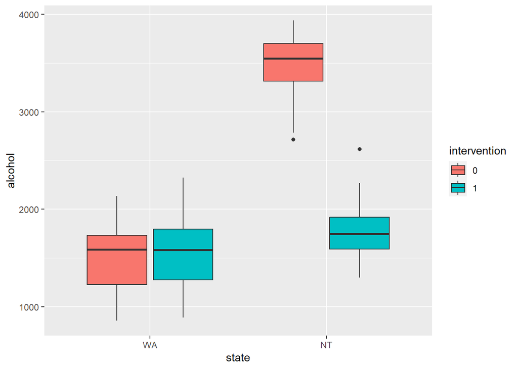

```r
#using the ggplot() function to visualize alcohol consumption level by state and by pre/post intervention.
ggplot(alc_mup_data) +
  geom_boxplot(aes(y=alcohol, x=state, fill = intervention))
```

The descriptive analysis suggests that alcohol minimum pricing likely reduced alcohol consumption in the population.

```r
#estimating the intervention effect of alcohol minimum pricing on population level alcohol consumption, using gls() function
res <- gls(alcohol ~ time*intervention*state,
           data = alc_mup_data,
           correlation = corARMA(p = 1, form =~ time | state), method = "ML")
summary(res)
```

```
## Generalized least squares fit by maximum likelihood
##   Model: alcohol ~ time * intervention * state
##   Data: alc_mup_data
##        AIC      BIC    logLik
##   1330.261 1355.905 -655.1307
##
## Correlation Structure: AR(1)
##  Formula: ~time | state
##  Parameter estimate(s):
##       Phi
## 0.7066424
##
## Coefficients:
##                                Value Std.Error   t-value p-value
## (Intercept)                 1558.506  263.2032  5.921303  0.0000
## time                           1.636   16.9157  0.096720  0.9232
## intervention1                -20.840  715.1188 -0.029143  0.9768
## stateNT                     2133.915  372.2256  5.732854  0.0000
## time:intervention1            -1.221   27.5750 -0.044281  0.9648
## time:stateNT                 -23.652   23.9224 -0.988718  0.3255
## intervention1:stateNT      -3258.232 1011.3307 -3.221728  0.0018
## time:intervention1:stateNT    62.170   38.9969  1.594227  0.1145
##
##  Correlation:
##                            (Intr) time   intrv1 statNT tm:nt1 tm:sNT in1:NT
## time                       -0.840
## intervention1              -0.507  0.639
## stateNT                    -0.707  0.594  0.358
## time:intervention1          0.600 -0.815 -0.945 -0.424
## time:stateNT                0.594 -0.707 -0.452 -0.840  0.576
## intervention1:stateNT       0.358 -0.452 -0.707 -0.507  0.668  0.639
## time:intervention1:stateNT -0.424  0.576  0.668  0.600 -0.707 -0.815 -0.945
##
## Standardized residuals:
##        Min         Q1        Med         Q3        Max
## -2.3167349 -0.8427548  0.0837754  0.6497867  2.4752763
##
## Residual standard error: 312.3269
## Degrees of freedom: 96 total; 88 residual
```

While alcohol consumption in the Northern Territory was higher than in Western Australia before alcohol minimum pricing, there was no significant difference in the pre-intervention trend (as indicated by the time by state interaction). Immediately after implementing minimum alcohol price, there was a significant drop in alcohol consumption in the Northern Territory but not in Western Australia (as indicated by the intervention by state interaction).

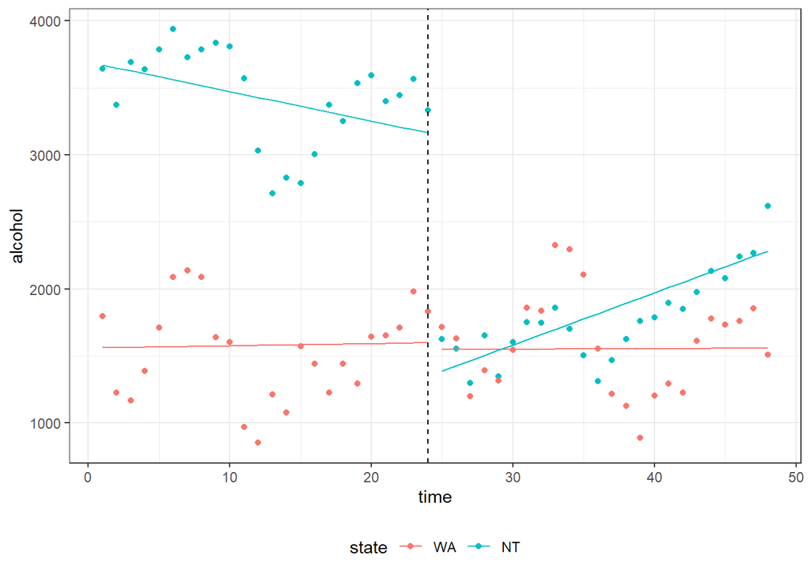

```r
#generating the model-based prediction
alc_mup_data$predicted <- res$fitted

#generating the interaction for ggplots
groups = interaction(alc_mup_data$intervention,alc_mup_data$state)

#ploting the time series
plot <- ggplot() +
  geom_point(data = alc_mup_data, aes(y = alcohol, x = time, color = state)) +
  geom_line(data = alc_mup_data, aes(y = predicted, x = time, color = state, group = groups)) +
  geom_vline(xintercept = max((alc_mup_data %>% filter(intervention == "0"))$time), linetype =
               "dashed") +
  theme_bw(base_family = "sans") +
  theme(legend.position = "bottom")
plot
```

#Our model has accounted for lag-1 autocorrelation. We can evaluate if this is sufficient using the partial auto-correlation function. The acf() can be used with the type parameter set to “partial”. In this analysis, we will need to plot the auto-correlation function for Western Australia and Northern Territory separately.

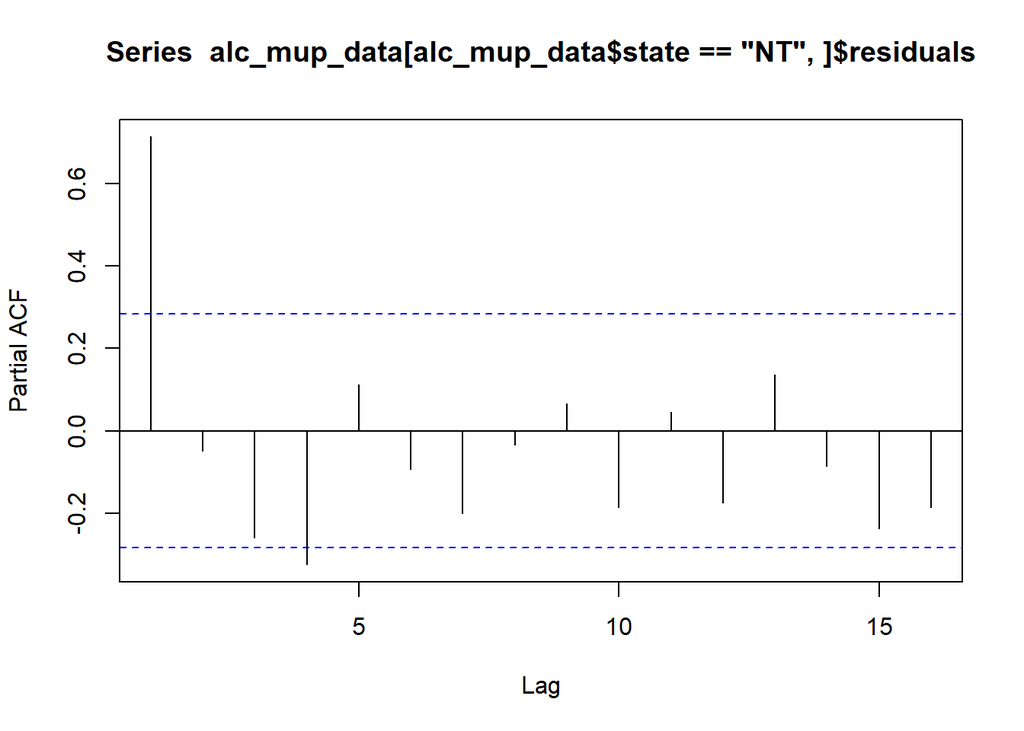

```r
#extract the residuals
alc_mup_data$residuals <- residuals(res)

#plotting the partial ACF
pacf(alc_mup_data[alc_mup_data$state == "NT",]$residuals)
```

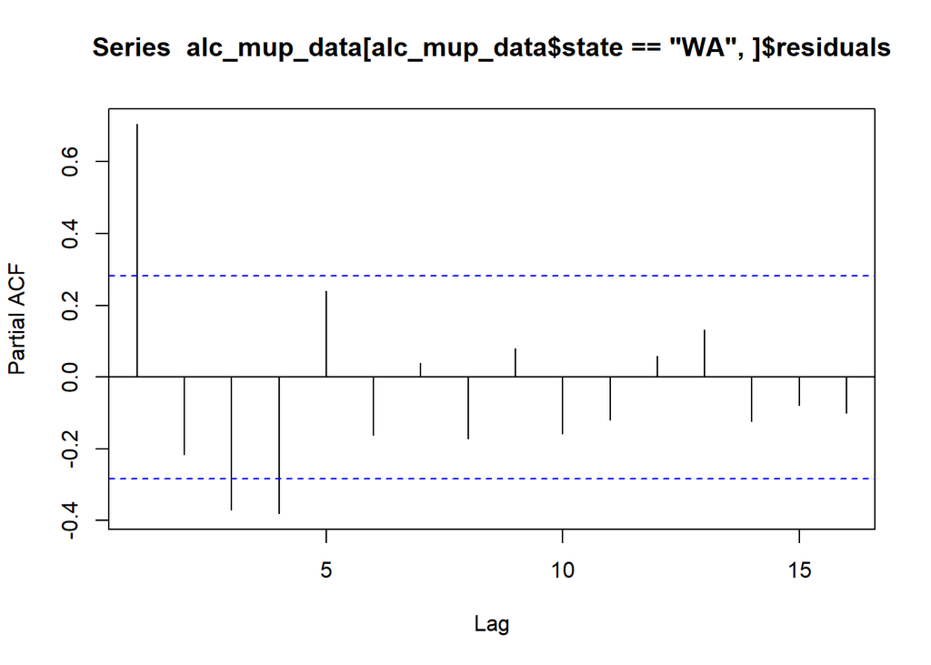

```r
pacf(alc_mup_data[alc_mup_data$state == "WA",]$residuals)
```

Autocorrelation measures how a variable is related to its past values and is a way to assess if there is a pattern or dependency within a time series.

```r
#Both PACF plots suggest that we should adjust for up to the lag-4 auto-correlation. The analysis can be rerun by setting the p parameter to 4, as follow.

res2 <- gls(alcohol ~ time*intervention*state,
            data = alc_mup_data,
            correlation = corARMA(p = 4, form =~ time | state), method = "ML")
summary(res2)
```

```
## Generalized least squares fit by maximum likelihood
##   Model: alcohol ~ time * intervention * state
##   Data: alc_mup_data
##        AIC      BIC    logLik
##   1304.056 1337.393 -639.0282
##
## Correlation Structure: ARMA(4,0)
##  Formula: ~time | state
##  Parameter estimate(s):
##        Phi1        Phi2        Phi3        Phi4
##  0.62015477  0.16715567 -0.07317626 -0.39203575
##
## Coefficients:
##                                Value Std.Error   t-value p-value
## (Intercept)                 1658.724  132.8975 12.481222  0.0000
## time                          -8.569    9.0656 -0.945170  0.3472
## intervention1                264.793  363.4460  0.728561  0.4682
## stateNT                     2066.230  187.9455 10.993769  0.0000
## time:intervention1            -1.092   13.2700 -0.082299  0.9346
## time:stateNT                 -14.494   12.8208 -1.130523  0.2613
## intervention1:stateNT      -3441.397  513.9903 -6.695452  0.0000
## time:intervention1:stateNT    58.177   18.7666  3.100037  0.0026
##
##  Correlation:
##                            (Intr) time   intrv1 statNT tm:nt1 tm:sNT in1:NT
## time                       -0.894
## intervention1              -0.417  0.394
## stateNT                    -0.707  0.632  0.295
## time:intervention1          0.647 -0.732 -0.895 -0.458
## time:stateNT                0.632 -0.707 -0.279 -0.894  0.518
## intervention1:stateNT       0.295 -0.279 -0.707 -0.417  0.633  0.394
## time:intervention1:stateNT -0.458  0.518  0.633  0.647 -0.707 -0.732 -0.895
##
## Standardized residuals:
##        Min         Q1        Med         Q3        Max
## -2.2969668 -0.7601198  0.1152635  0.7156477  2.3217466
##
## Residual standard error: 310.0007
## Degrees of freedom: 96 total; 88 residual
```

```r
#adjust for seasonality



#The harmonic function is used to calculate the harmonic terms calculate based on sine and cosine function
#the first parameter of this function specifies the time variable
#the second specifies the number of sine and cosine pairs to include
#the third specifies the length of the period

alc_mup_data <- cbind(alc_mup_data, data.frame(harmonic(alc_mup_data$time, 1, 12)))
alc_mup_data <- alc_mup_data %>%
  rename(harmonic1 = X1,
         harmonic2 = X2)
res <- gls(alcohol ~ time*intervention*state + harmonic1 + harmonic2,
           data = alc_mup_data,
           correlation = corARMA(p = 1, form =~ time | state), method = "ML")
summary(res)
```

```
## Generalized least squares fit by maximum likelihood
##   Model: alcohol ~ time * intervention * state + harmonic1 + harmonic2
##   Data: alc_mup_data
##       AIC      BIC   logLik
##   1313.75 1344.522 -644.875
##
## Correlation Structure: AR(1)
##  Formula: ~time | state
##  Parameter estimate(s):
##       Phi
## 0.6162917
##
## Coefficients:
##                                Value Std.Error   t-value p-value
## (Intercept)                 1665.579  197.7979  8.420607  0.0000
## time                          -7.244   13.0538 -0.554900  0.5804
## intervention1                142.751  541.7217  0.263513  0.7928
## stateNT                     2146.874  277.3498  7.740673  0.0000
## harmonic1                   -267.374   57.3382 -4.663114  0.0000
## harmonic2                    -27.005   53.3816 -0.505882  0.6142
## time:intervention1             0.474   20.4244  0.023186  0.9816
## time:stateNT                 -22.924   18.2655 -1.255060  0.2129
## intervention1:stateNT      -3284.316  762.7561 -4.305853  0.0000
## time:intervention1:stateNT    61.114   28.8323  2.119624  0.0369
##
##  Correlation:
##                            (Intr) time   intrv1 statNT hrmnc1 hrmnc2 tm:nt1
## time                       -0.853
## intervention1              -0.468  0.540
## stateNT                    -0.701  0.595  0.338
## harmonic1                  -0.128  0.145 -0.060  0.000
## harmonic2                  -0.017  0.007  0.074  0.000 -0.041
## time:intervention1          0.609 -0.782 -0.924 -0.432 -0.014 -0.058
## time:stateNT                0.596 -0.700 -0.391 -0.850  0.000  0.000  0.557
## intervention1:stateNT       0.336 -0.389 -0.704 -0.480  0.000  0.000  0.654
## time:intervention1:stateNT -0.429  0.552  0.652  0.612  0.000  0.000 -0.706
##                            tm:sNT in1:NT
## time
## intervention1
## stateNT
## harmonic1
## harmonic2
## time:intervention1
## time:stateNT
## intervention1:stateNT       0.556
## time:intervention1:stateNT -0.789 -0.926
##
## Standardized residuals:
##        Min         Q1        Med         Q3        Max
## -2.8783266 -0.7063188 -0.1231168  0.6723216  1.9645475
##
## Residual standard error: 252.7503
## Degrees of freedom: 96 total; 86 residual
```

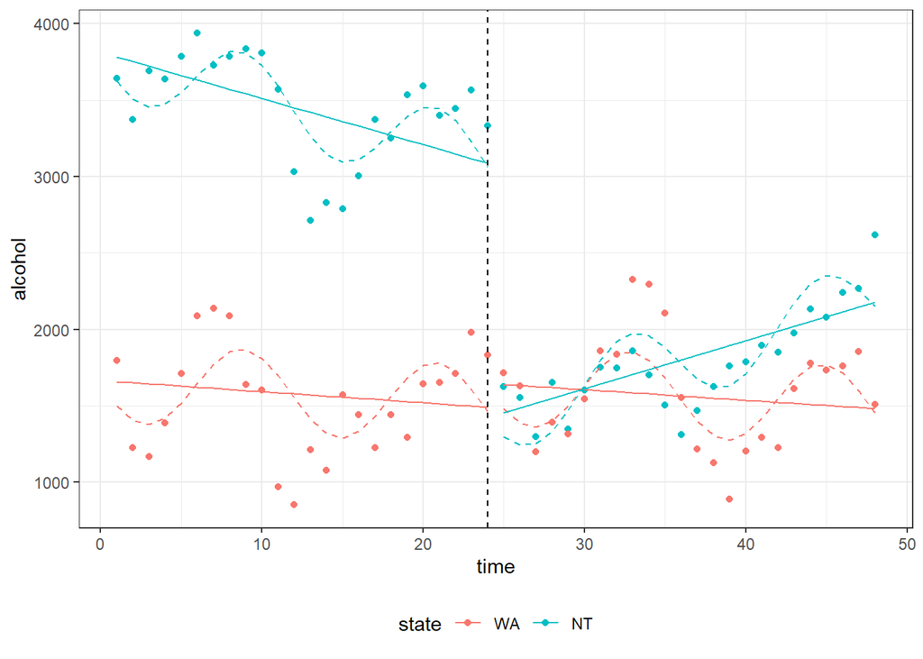

```r
#calculate the predicted value
alc_mup_data$predicted <- res$fitted
groups = interaction(alc_mup_data$intervention,alc_mup_data$state)

#calculate the predicted linear trend for data visualisation
alc_mup_data.linear <- alc_mup_data
alc_mup_data.linear$harmonic1 <- 0
alc_mup_data.linear$harmonic2 <- 0
alc_mup_data.linear$predicted <- predict(res, alc_mup_data.linear)

#plot the time series
plot <- ggplot() +
  geom_point(data = alc_mup_data, aes(y = alcohol, x = time, color = state)) +
  geom_line(data = alc_mup_data, aes(y = predicted, x = time, color = state, group = groups), linetype = "dashed") +
  geom_line(data = alc_mup_data.linear, aes(y = predicted, x = time, color = state, group = groups)) +
  geom_vline(xintercept = max((alc_mup_data %>% filter(intervention == "0"))$time), linetype = "dashed") +
  theme_bw(base_family = "sans") +
  theme(legend.position = "bottom")
plot
```